# Relationship Between Words

Reference book: https://www.tidytextmining.com/

```r
library(tidytext)
library(tidyverse)
```

Many interesting text analyses are based on the **relationships between words**, whether examining which words tend to follow others immediately, or that tend to co-occur within the same documents.

### Tokenizing by n-gram

We will use the `token = "ngrams"` argument in the `unnest_tokens()`, which tokenizes by pairs of adjacent words rather than by individual ones. This allows us to tokenize into consecutive sequences of words, called **n-grams**.

By seeing how often word `X` is followed by word `Y`, we can then build a model of the relationships between them. The parameter `n` is the number of words we wish to capture in each n-gram, and we will start by seting `n` to 2, to indicate we are examining *pairs of two consecutive words*, often called *bigrams*:

```r
rmp <- read_csv("https://raw.githubusercontent.com/reisanar/datasets/master/rmp_wit_comments.csv")
```

Bigrams:

```r
rmp_bigrams <- rmp %>%
  unnest_tokens(bigram, comments,
                token = "ngrams", n = 2)
```

Check the results of this tokenization:

```r
rmp_bigrams
```

| course | bigram |
| --- | --- |
| MATH1900 | he is |
| MATH1900 | is very |
| MATH1900 | very enthusiastic |
| MATH1900 | enthusiastic to |
| MATH1900 | to help |
| MATH1900 | help students |
| MATH1900 | students his |
| MATH1900 | his course |
| MATH1900 | course content |
| MATH1900 | content is |

[output cut: 808 more lines]

#### Counting and filtering n-grams

Our usual tidy tools apply equally well to n-gram analysis. We can examine the most common bigrams using `dplyr`s `count()`:

```r
rmp_bigrams %>%
  count(bigram, sort = TRUE)
```

| bigram | n |
| --- | --- |
| he is | 14 |
| great professor | 8 |
| is a | 7 |
| a great | 5 |
| i would | 5 |
| the material | 5 |
| if you | 4 |
| is very | 4 |
| lectures are | 4 |
| professor he | 4 |

[output cut: 694 more lines]

As one might expect, a lot of the most common bigrams are pairs of common (uninteresting) words, such as `to a`: what we call stop-words

We can use `tidyr`s `separate()` function, which splits a column into multiple based on a delimiter. This lets us separate it into two columns, say `word1` and `word2`, at which point we can remove cases where either is a stop-word.

```r
rmp_bigrams %>%
  separate(bigram, into = c("word1", "word2"), sep = " ")
```

| course | word1 | word2 |
| --- | --- | --- |
| MATH1900 | he | is |
| MATH1900 | is | very |
| MATH1900 | very | enthusiastic |
| MATH1900 | enthusiastic | to |
| MATH1900 | to | help |
| MATH1900 | help | students |
| MATH1900 | students | his |
| MATH1900 | his | course |
| MATH1900 | course | content |
| MATH1900 | content | is |

[output cut: 808 more lines]

Let us remove the stop-words using the `filter()` function

```r
bigrams_filtered <- rmp_bigrams %>%
    separate(bigram, into = c("word1", "word2"), sep = " ") %>%
    filter(!word1 %in% stop_words$word) %>%
    filter(!word2 %in% stop_words$word)
```

Count again:

```r
# new bigram counts:
bigram_counts <- bigrams_filtered %>%
  count(word1, word2, sort = TRUE)

bigram_counts
```

| word1 | word2 | n |
| --- | --- | --- |
| pre | calc | 3 |
| linear | algebra | 2 |
| makes | class | 2 |
| pay | attention | 2 |
| awesome | professor | 1 |
| awesome | teacher | 1 |
| brain | easy | 1 |
| calc | skills | 1 |
| class | entertained | 1 |
| class | relates | 1 |

[output cut: 53 more lines]

In other analyses, we may want to work with the recombined words. `tidyr`’s `unite()` function is the inverse of `separate()`, and allows us to recombine the columns into one.

```r
bigrams_united <- bigrams_filtered %>%
  unite(bigram, word1, word2, sep = " ")

bigrams_united
```

| course | bigram |
| --- | --- |
| MATH1900 | email communication |
| MATH1900 | office hour |
| MATH1900 | awesome teacher |
| MATH250 | notes online |
| MATH2860 | pretty easy |
| MATH2860 | professor challenging |
| MATH2860 | mixes humor |
| MATH2860 | makes class |
| MATH2860 | pay attention |
| MATH2860 | linear algebra |

[output cut: 58 more lines]

In other analyses you may be interested in the most common *trigrams*, which are consecutive sequences of 3 words. We can find this by setting `n = 3`:

```r
rmp %>%
  unnest_tokens(trigram, comments, token = "ngrams", n = 3) %>%
  separate(trigram, c("word1", "word2", "word3"), sep = " ") %>%
  filter(!word1 %in% stop_words$word,
         !word2 %in% stop_words$word, !word3 %in% stop_words$word) %>%
  count(word1, word2, word3, sort = TRUE)
```

| word1 | word2 | word3 | n |
| --- | --- | --- | --- |
| communicator | powerpoint | lectures | 1 |
| easy | short | online | 1 |
| funny | explains | concepts | 1 |
| grade | makes | class | 1 |
| occasional | fun | games | 1 |
| professor | occasional | fun | 1 |
| short | online | homeworks | 1 |
| simple | easy | short | 1 |
| students | funny | explains | 1 |
| taking | linear | algebra | 1 |

[output cut: 1 more lines]

```r
NA
```

### Analyzing bigrams

A bigram can also be treated as a *term* in a document in the same way that we treated individual words. For example, we can look at the `tf-idf` of bigrams.

```r
bigram_tf_idf <- bigrams_united %>%
  count(course, bigram) %>%
  bind_tf_idf(bigram, course, n) %>%
  arrange(desc(tf_idf))

bigram_tf_idf
```

| course | bigram | n | tf | idf | tf_idf |
| --- | --- | --- | --- | --- | --- |
| MATH310 | favorite professors | 1 | 0.50000000 | 1.945910 | 0.97295507 |
| MATH310 | funny guy | 1 | 0.50000000 | 1.945910 | 0.97295507 |
| MATH250 | pre calc | 3 | 0.37500000 | 1.945910 | 0.72971631 |
| MATH1900 | awesome teacher | 1 | 0.33333333 | 1.945910 | 0.64863672 |
| MATH1900 | email communication | 1 | 0.33333333 | 1.945910 | 0.64863672 |
| MATH1900 | office hour | 1 | 0.33333333 | 1.945910 | 0.64863672 |
| MATH2025 | calc skills | 1 | 0.20000000 | 1.945910 | 0.38918203 |
| MATH2025 | class entertained | 1 | 0.20000000 | 1.945910 | 0.38918203 |
| MATH2025 | easiest stuff | 1 | 0.20000000 | 1.945910 | 0.38918203 |
| MATH2025 | professor calculus | 1 | 0.20000000 | 1.945910 | 0.38918203 |

[output cut: 54 more lines]

Let us check the bigrams with the highest tf-idf:

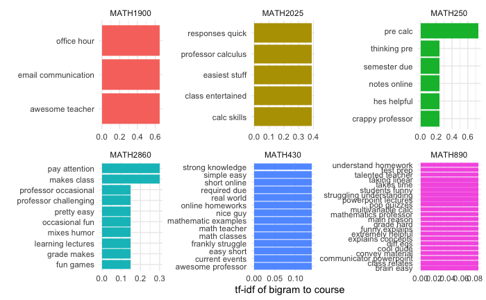

```r
bigram_tf_idf %>%
  arrange(desc(tf_idf)) %>%
  group_by(course) %>%
  top_n(10, tf_idf) %>%
  ungroup() %>%
  mutate(bigram = reorder(bigram, tf_idf)) %>%
  filter(course != "MATH310") %>%
  ggplot(aes(bigram, tf_idf, fill = course)) +
  geom_col(show.legend = FALSE) +
  facet_wrap(~ course, ncol = 3, scales = "free") +
  coord_flip() +
  labs(y = "tf-idf of bigram to course",
       x = "") +
  theme_minimal()
```

There are advantages and disadvantages to examining the tf-idf of bigrams rather than individual words. Pairs of consecutive words might capture structure that is not present when one is just counting single words, and may provide context that makes tokens more understandable. However, the per-bigram counts are also sparser: a typical two-word pair is rarer than either of its component words. Thus, bigrams can be especially useful when you have a very large text dataset.

### Using bigrams to provide context in sentiment analysis

One of the problems with sentiment analysis using uni-grams, is illustrated below:

For example, the words “happy” and “like” will be counted as positive, even in a sentence like “I’m not happy and I don’t like it!”

```r
bigrams_separated <- rmp_bigrams %>%
  separate(bigram, into = c("word1", "word2"), sep = " ")
```

Now that we have the data organized into bigrams, it is easy to tell how often words are preceded by a word like “not”:

```r
bigrams_separated %>%
  filter(word1 == "not") %>%
  count(word1, word2, sort = TRUE)
```

| word1 | word2 | n |
| --- | --- | --- |
| not | a | 1 |
| not | difficult | 1 |
| not | often | 1 |
| not | one | 1 |
| not | only | 1 |
| not | really | 1 |

```r
NA
```

By performing sentiment analysis on the bigram data, we can examine how often sentiment-associated words are preceded by “not” or other negating words. We could use this to ignore or even reverse their contribution to the sentiment score.

Let us use the AFINN lexicon for sentiment analysis (recall that this lexicon gives a numeric sentiment score for each word, with positive or negative numbers indicating the direction of the sentiment).

```r
AFINN <- get_sentiments("afinn")
# print a sample of words and scores
sample_n(AFINN, 5)
```

| word | value |
| --- | --- |
| worried | -3 |
| exploits | -2 |
| hiding | -1 |
| joyful | 3 |
| terrific | 4 |

We can then examine the most frequent words that were preceded by “not” and were associated with a sentiment.

```r
bb_lyrics <- read_csv("https://raw.githubusercontent.com/reisanar/datasets/master/BB_top100_2015.csv")
```

```r
# bigrams count
not_words <- bb_lyrics %>%
  unnest_tokens(bigram, Lyrics, token = "ngrams", n = 2) %>%
  separate(bigram, into = c("word1", "word2"), sep = " ") %>%
  filter(word1 == "not") %>%
  inner_join(AFINN, by = c(word2 = "word")) %>%
  count(word2, value, sort = TRUE)
```

For example, the most common sentiment-associated word to follow “not” was “leave”, which would normally have a (negative) score of -1.

```r
not_words
```

| word2 | value | n |
| --- | --- | --- |
| leave | -1 | 4 |
| promised | 1 | 2 |
| scared | -2 | 2 |
| alive | 1 | 1 |
| good | 3 | 1 |
| important | 2 | 1 |
| insane | -2 | 1 |
| like | 2 | 1 |

Notice that “like” also appears, which would have a (positive) score of 2.

It is worth asking which words contributed the most in the “wrong” direction. To compute that, we can multiply their score by the number of times they appear (so that a word with a score of +3 occurring 10 times has as much impact as a word with a sentiment score of +1 occurring 30 times). We visualize the result with a bar plot

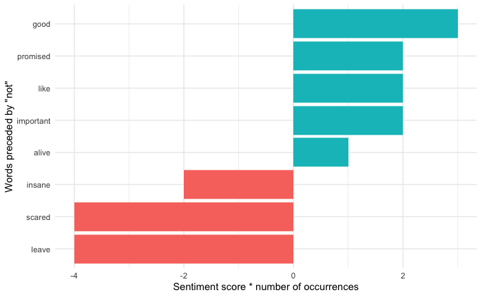

```r
not_words %>%
  mutate(contribution = n * value) %>%
  arrange(desc(abs(contribution))) %>%
  head(20) %>%
  mutate(word2 = reorder(word2, contribution)) %>%
  ggplot(aes(word2, n * value, fill = n * value > 0)) +
  geom_col(show.legend = FALSE) +
  xlab("Words preceded by \"not\"") +
  ylab("Sentiment score * number of occurrences") +
  coord_flip() +
  theme_minimal()
```

The words preceded by “not” that had the greatest contribution to sentiment scores, in either a positive or negative direction.

“Not” is not the only term that provides some context for the following word. We could pick four common words (or more) that negate the subsequent term, and use the same joining and counting approach to examine all of them at once.

```r
negation_words <- c("not", "no", "never", "without")
```

```r
negated_words <- bb_lyrics %>%
  unnest_tokens(bigram, Lyrics, token = "ngrams", n = 2) %>%
  separate(bigram, into = c("word1", "word2"), sep = " ") %>%
  filter(word1 %in% negation_words) %>%
  inner_join(AFINN, by = c(word2 = "word")) %>%
  count(word1, word2, value, sort = TRUE)
```

```r
negated_words
```

| word1 | word2 | value | n |
| --- | --- | --- | --- |
| no | no | -1 | 5 |
| not | leave | -1 | 4 |
| no | disrespect | -2 | 3 |
| never | broken | -1 | 2 |
| never | drop | -1 | 2 |
| no | fool | -2 | 2 |
| no | regrets | -2 | 2 |
| not | promised | 1 | 2 |
| not | scared | -2 | 2 |
| never | alone | -2 | 1 |

[output cut: 17 more lines]

We could then visualize what the most common words to follow each particular negation are.

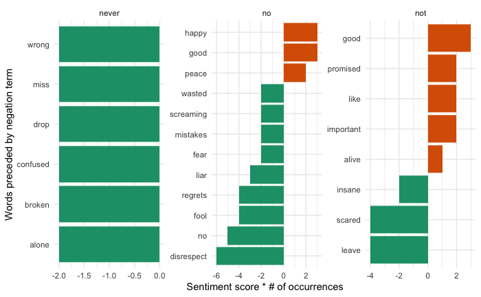

```r
negated_words %>%
  mutate(contribution = n * value) %>%
  group_by(word1) %>%
  top_n(12, abs(contribution)) %>%
  ggplot(aes(x = reorder(word2, contribution), y = contribution, fill = n * value > 0)) +
  scale_fill_brewer(palette = "Dark2") +
  geom_col(show.legend = FALSE) +
  facet_wrap(~ word1, scales = "free") +
  xlab("Words preceded by negation term") +
  ylab("Sentiment score * # of occurrences") +
  coord_flip() +
  theme_minimal()
```

These are just a few examples of how finding consecutive words can give context to text mining methods.